# A prototypic machine leaning analysis - Reanalyis of “Mindful Machine Learning”

Sebastian Sauer

2019-10-21

# Scope

This is the re-analysis of this paper

Sauer, S., Buettner, R., Heidenreich, T., Lemke, J., Berg, C., & Kurz, C. (2018). Mindful machine learning: Using machine learning algorithms to predict the practice of mindfulness. European Journal of Psychological Assessment, 34(1), 6-13. http://dx.doi.org/10.1027/1015-5759/a000312

A colleague ([Dr. Florian Pargent](http://www.psy.lmu.de/pm/personen/lehrstuhlmitarbeiter/pargent/index.html)) informed me about an potential error in my analysis. Having checked it, I confirm that there is an error in the initial analyses.

Specifically, he informed me that the performance measures appear to be based on on the *train* sample, where the *test* sample should have been used.

After having checked the original code, I agree with Dr. Pargent notion. Specifically, in *each model*, the *training* data has been presented, but not the *testing* data as it should have been.

The following code documents the re-analyses that now employs the *testing* data for gauging model performance.

# Cautions

The following aspects could not been controlled:

- Package versions
- R version

It seems unlikely though not completely impossible that these factors possibly influence the results. However, we deem the possible influence of those factor negligible.

# Aim of this post

Correcting the literature is taking place elsewhere; he I would like to show a somewhat typical flow of analysis in machine learning for prediction. I think the code is quite straight forward and should be easy to generalize to similar problems.

# Accessibility

This code, alongside with the data, can be openly accessed from this repository: https://github.com/sebastiansauer/reanalysis-mindful-machine-learning

# Setup

## Init

```r
knitr::opts_chunk$set(
  comment = "#>",
  collapse = TRUE,
  message = FALSE,
  warning = FALSE,
  cache = TRUE,
  results = "hide",
  out.width = "70%",
  fig.align = 'center',
  fig.width = 6,
  fig.asp = 0.618,  # 1 / phi
  fig.show = "hold",
  size = "tiny"
)
```

Load libs:

```r
library(conflicted)
library(caret)
library(here)
library(tictoc)
library(testthat)
library(tidyverse)
library(drlib)
```

## Define constants

```r
output_filename <- "model_performance.Rds"
```

## Load original data

```r
dat_url <- "https://raw.github.com/sebastiansauer/reanalysis-mindful-machine-learning/master/original-data/1015-5759_a000312_esm5.csv"

dat <- read_csv(dat_url)
```

## Prepare data

### Set DV to type `factor`

As `caret` will only do classificiton if the outcome is of type factor, we need to convert the outcome variable `practice` to factor.

```r
dat2 <- dat %>%
  mutate(practice = factor(practice),
         practice = case_when(
           practice == "1" ~ "yes",
           practice == "0" ~ "no"
         ),
         practice = factor(practice)) %>%
  dplyr::select(practice, everything()) %>%
  dplyr::select(-X1)

glimpse(dat2)
```

```
#> Observations: 276
#> Variables: 15
#> $ practice <fct> no, no, yes, no, no, no, yes, no, yes, no, yes, yes, no…
#> $ fmi1     <dbl> 0.6, 0.8, 0.8, 1.0, 0.6, 0.4, 1.0, 0.4, 1.0, 1.0, 0.6, …
#> $ fmi2     <dbl> 0.8, 0.6, 0.4, 0.0, 0.6, 0.2, 0.8, 0.0, 0.8, 0.6, 0.2, …
#> $ fmi3     <dbl> 0.4, 1.0, 0.6, 0.2, 0.2, 0.4, 0.8, 0.0, 0.8, 1.0, 0.6, …
#> $ fmi4     <dbl> 0.0, 1.0, 1.0, 0.2, 0.2, 0.8, 0.8, 0.6, 0.8, 1.0, 0.6, …
#> $ fmi5     <dbl> 0.2, 0.8, 0.8, 0.2, 1.0, 0.8, 0.6, 0.4, 0.8, 1.0, 0.8, …
#> $ fmi6     <dbl> 0.4, 0.0, 1.0, 0.0, 0.2, 0.8, 0.6, 0.4, 0.6, 1.0, 0.8, …
#> $ fmi7     <dbl> 0.6, 0.6, 0.6, 0.2, 0.8, 0.4, 0.8, 0.2, 1.0, 1.0, 0.8, …
#> $ fmi8     <dbl> 0.8, 0.2, 0.4, 0.8, 0.6, 0.6, 0.6, 0.2, 0.8, 1.0, 0.8, …
#> $ fmi9     <dbl> 1.0, 0.6, 1.0, 0.2, 0.4, 0.6, 0.6, 0.2, 0.2, 1.0, 0.8, …
#> $ fmi10    <dbl> 0.0, 0.4, 0.8, 0.2, 0.4, 0.4, 0.8, 0.2, 0.8, 1.0, 0.6, …
#> $ fmi11    <dbl> 0.4, 1.0, 0.4, 0.4, 0.6, 0.2, 0.8, 0.2, 0.6, 1.0, 0.6, …
#> $ fmi12    <dbl> 0.4, 0.4, 1.0, 0.0, 0.4, 0.2, 0.8, 0.0, 0.0, 1.0, 0.8, …
#> $ fmi13    <dbl> 0.8, 0.8, 0.4, 0.8, 1.0, 0.8, 0.4, 0.4, 0.6, 0.0, 0.8, …
#> $ fmi14    <dbl> 0.6, 0.8, 1.0, 0.8, 1.0, 0.6, 1.0, 0.6, 0.8, 1.0, 0.8, …
```

### Ensure valide factor levels

The factor levels should be proper R names for some caret models, accoring to [this source](https://www.kaggle.com/c/15-071x-the-analytics-edge-competition-spring-2015/discussion/13964), see also [this SO post](https://stackoverflow.com/questions/18402016/error-when-i-try-to-predict-class-probabilities-in-r-caret).

The dependent variable should be of type `factor` and needs valid factor levels [as stated in this SO post](https://stackoverflow.com/questions/18402016/error-when-i-try-to-predict-class-probabilities-in-r-caret). Let’s check that.

```r
levels(dat2$practice) <- make.names(levels(factor(dat2$practice)))
levels(dat2$practice)
```

```
#> [1] "no"  "yes"
```

Check that all predictors are metric, and that the DV is of type factor.

Define vector of predictor names:

```r
predictor_names <- c(paste0("fmi", 1:14))
predictor_names
```

Test for correct length:

```r
test_dat2 <- dat2 %>%
  map( ~class(.))

expect_length(test_dat2, n = (length(predictor_names) + 1))
```

# Training vs test sample

```r
inTraining <- createDataPartition(dat2$practice, p = 0.8, list = FALSE)
training <- dat2[inTraining, ]
testing <- dat2[-inTraining, ]
```

## Define model list

```r
model_list <- c("glm", "gbm", "qda", "svmLinear", "svmPoly", "rf", "nnet", "ada", "knn", "elm")

n_models <- length(model_list)
n_models
```

There are 10 being tested.

## Define standard cross-validation scheme

```r
fitControl <- trainControl(## 10-fold CV
    method = "repeatedcv",
    number = 10,
    ## repeated ten times
    repeats = 10)
```

## Define data objects for results

```r
conf.all <- data.frame(matrix(nrow = 10, ncol = 4))
names(conf.all) <- c("model", "sensitivity", "specificity", "kappa")


model_output <- list()

model_confmatrix <- list()
```

# funs

This function stores the model output in some lists:

```r
# delete-me
save_model_output <- function(name, modelOut) {

  model_confmatrix[[name]] <<- confusionMatrix(predict(modelOut, testing),
                                             testing$practice)

  conf.all[name, ] <<- c(name, model_confmatrix[[name]][c(1,2)], model_confmatrix[[name]]$overall[2])

}
```

```r
run_model <- function(model_name, ...){

  set.seed(42)

  start_time = Sys.time()

  modelOut <- train(practice ~ .,
                    data = training,
                    method = model_name,
                    trControl = fitControl,
                    ...)

  modelPred <- predict(modelOut, testing)

  modelConfMatrix <- confusionMatrix(modelPred, testing$practice)

  end_time = Sys.time()

  coefs <- list(name = model_name,
                sensitivity = modelConfMatrix$byClass[1],
                specificity = modelConfMatrix$byClass[2],
                accuracy = modelConfMatrix$overall[1],
                kappa = modelConfMatrix$overall[2],
                time_taken = end_time - start_time)
}
```

# Now run the models

## Check

```r
modelOut <- train(practice ~ .,
                  data = training,
                  method = "glm",
                  trControl = fitControl,
                  family = "binomial")

modelPred <- predict(modelOut, testing)

modelConfMatrix <- confusionMatrix(modelPred, testing$practice)
modelConfMatrix
```

```
#> Confusion Matrix and Statistics
#>
#>           Reference
#> Prediction no yes
#>        no  29  11
#>        yes  4  11
#>
#>                Accuracy : 0.7273
#>                  95% CI : (0.5904, 0.8386)
#>     No Information Rate : 0.6
#>     P-Value [Acc > NIR] : 0.0346
#>
#>                   Kappa : 0.4
#>
#>  Mcnemar's Test P-Value : 0.1213
#>
#>             Sensitivity : 0.8788
#>             Specificity : 0.5000
#>          Pos Pred Value : 0.7250
#>          Neg Pred Value : 0.7333
#>              Prevalence : 0.6000
#>          Detection Rate : 0.5273
#>    Detection Prevalence : 0.7273
#>       Balanced Accuracy : 0.6894
#>
#>        'Positive' Class : no
#>
```

```r
modelConfMatrix$byClass[c(1,2)]
```

```
#> Sensitivity Specificity
#>   0.8787879   0.5000000
```

```r
modelConfMatrix$overall[c(1,2)]
```

```
#>  Accuracy     Kappa
#> 0.7272727 0.4000000
```

## Check - GLM

```r
model_output[["glm"]] <- run_model("glm", family = "binomial")

model_output[["glm"]]
```

## Loop over models

```r
if (!file.exists(paste0(here(),"/MML/reanalysis-objects/", output_filename))) {
  time <- Sys.time()
  model_performance <- model_list %>%
    map_dfr(run_model)

  Sys.time() - time
} else {cat("Output file already exists. Skipping re-computation. Loading output file.\n")
  model_performance <- read_rds(paste0(here(),"/reanalysis-objects/", output_filename) )}
```

## Check results

```r
model_performance
```

## Own music for Boosting

Define different grid to check hyper parameter:

```r
gbmGrid <-  expand.grid(interaction.depth = c(1, 5, 9),
                        n.trees = 1:30*50,
                        shrinkage = 0.1,
                        n.minobsinnode = 10)

performance_gbm <- run_model("gbm", tuneGrid = gbmGrid)


performance_gbm_df <- flatten(performance_gbm) %>%
  as_tibble()
```

Now add the gbm results to the main performance data frame, that is, replace the old values by the new one:

```r
model_performance2 <- model_performance


model_performance2[performance_gbm_df$name == model_performance2$name, ] <- performance_gbm_df


model_performance2
```

# Visualize model performance

## Reformat data

Now spread it into a long format.

```r
model_performance_long <- model_performance2 %>%
  pivot_longer(cols = sensitivity:kappa, names_to = "coefficient", values_to = "value")
model_performance_long
```

## Check

```r
model_performance_long %>%
  count(name)
```

Looks good, 4 coefficients per model (name).

Similarly,

```r
model_performance_long %>%
  count(coefficient)
```

## Figure 2 (original paper)

Now plot:

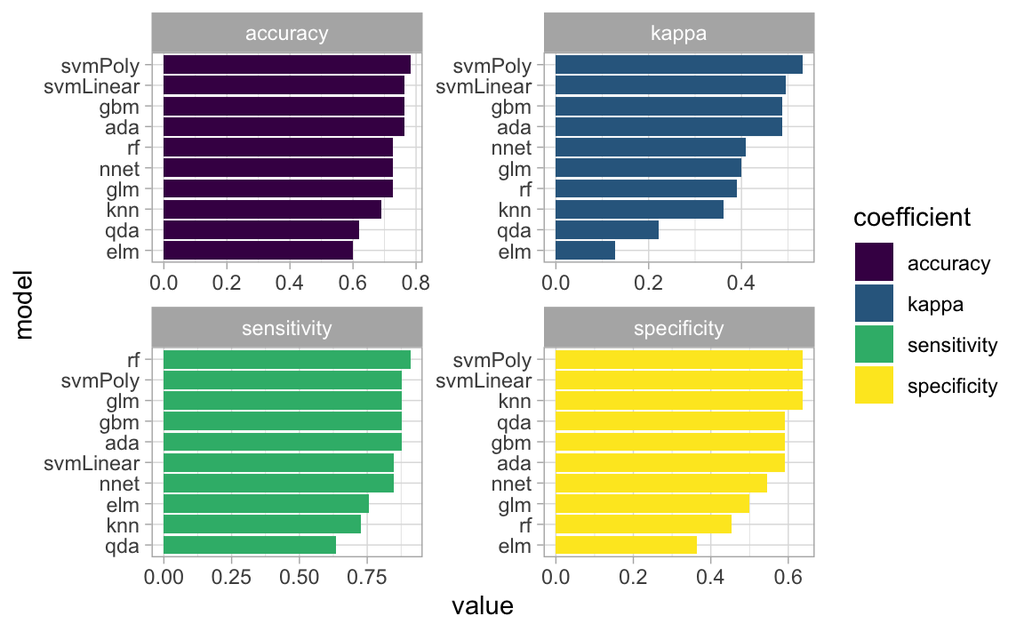

```r
model_performance_long %>%
  #dplyr::filter(coefficient != "accuracy") %>%
  ggplot(aes(x = reorder_within(name, value, coefficient), y = value, fill = coefficient)) +
  geom_col(position = "dodge") +
  coord_flip() +
  scale_fill_viridis_d() +
  scale_x_reordered() +
  theme_light() +
  labs(x = "model", y = "value") +
  facet_wrap(~ coefficient, scales = "free")
```

## Figure 3

Figure 3 in the original paper computes the average per coefficient across all models, and compares “classical” linear model results with the “machine learning” models.

First compute the summary stats.

```r
model_output_df_sum <- model_performance_long %>%
  mutate(type = ifelse(name == "glm", "classical", "machine learning")) %>%
  group_by(type, coefficient) %>%
  summarise(cofficient_mean = mean(value))

model_output_df_sum
```

Now plot.

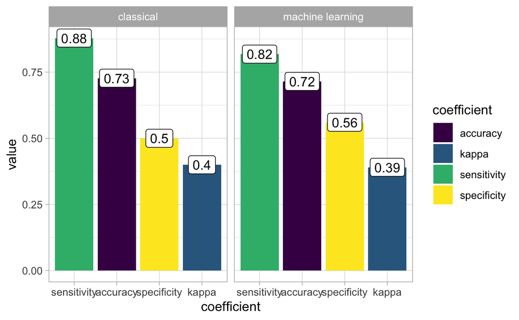

```r
model_output_df_sum %>%
  ggplot(aes(x = reorder(coefficient, -cofficient_mean), y = cofficient_mean)) +
  geom_col(position = "dodge", aes(fill = coefficient)) +
  facet_wrap(~ type) +
  scale_fill_viridis_d() +
  theme_light() +
  labs(y = "value", x = "coefficient") +
  geom_label(aes(label = round(cofficient_mean, 2)))
```

As concluded in the original paper, algorithms do differ in their performance given a particular data set. Analysts should be aware of the variation in the results induced by picking one ore more certain models.

# Computation time

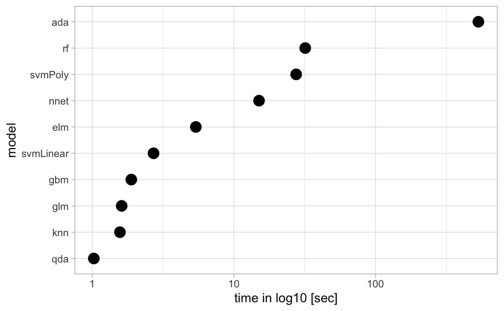

```r
model_performance2 %>%
  mutate(time = as.numeric(time_taken)) %>%
  ggplot(aes(x = reorder(name, time), y = time)) +
  geom_point(size = 4) +
  coord_flip() +
  theme_light() +
  scale_y_log10() +
  labs(y = "time in log10 [sec]", x = "model")
```

# Write output to disk

```r
#model_output <- read_rds("reanalysis-objects/model_output.rds")
#write_rds(model_performance, paste0(here(),"/MML/reanalysis-objects/", output_filename))
```